# ESM 263 HW2

Linus Blomqvist

2021-01-26

### Loading and exploring data

Check what layers are in the basemap:

```r
st_layers("HW2/data_hw2/basemap.gpkg")$name
```

```
## [1] "California" "Cities"     "County"     "ROI"        "Streets"
```

Read them in:

```r
california <- read_sf("HW2/data_hw2/basemap.gpkg", layer = "California")
cities <- read_sf("HW2/data_hw2/basemap.gpkg", layer = "Cities")
county <- read_sf("HW2/data_hw2/basemap.gpkg", layer = "County")
ROI <- read_sf("HW2/data_hw2/basemap.gpkg", layer = "ROI")
streets <- read_sf("HW2/data_hw2/basemap.gpkg", layer = "streets")
```

For this and any other layers we can do a little exploring. For example, we can check the variable names:

```r
names(california)
```

```
##  [1] "OBJECTID"     "NAME_PCASE"   "NAME_UCASE"   "FMNAME_PC"    "FMNAME_UC"
##  [6] "ABBREV"       "NUM"          "ABCODE"       "FIPS"         "ANSI"
## [11] "ISLAND"       "Shape_Leng"   "Shape_Length" "Shape_Area"   "geom"
```

Note that in an `sf` object, there’s always a column at the end called `geom`; this contains all the spatial information.

We can also do a quick plot to see what we have. Looks like counties.

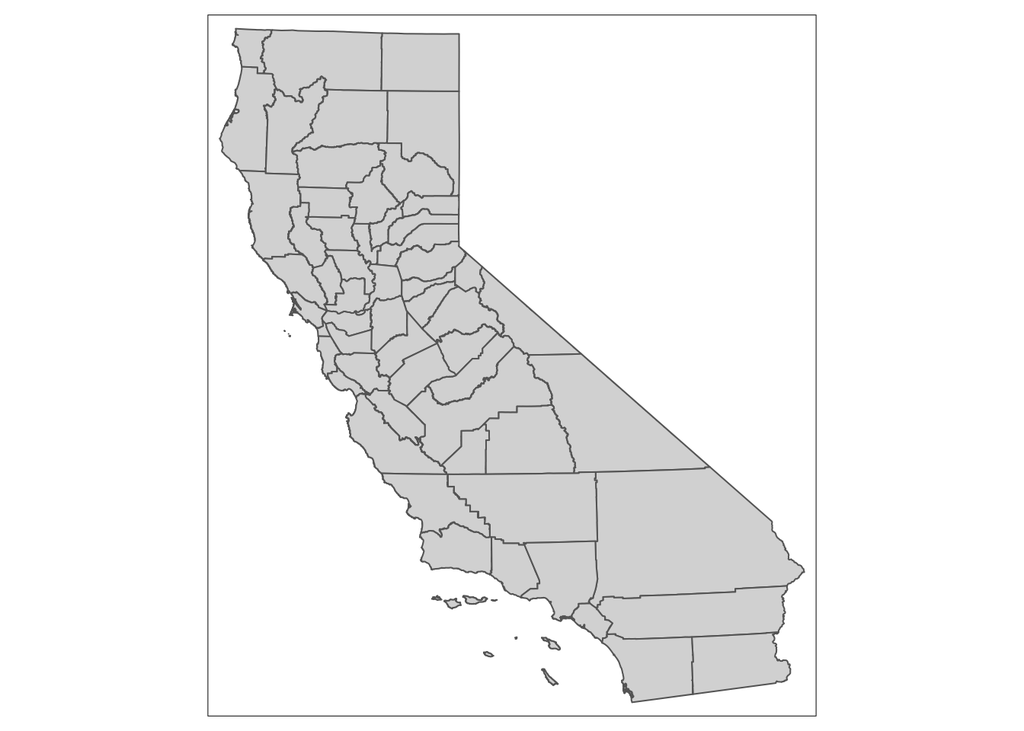

```r
tm_shape(st_geometry(california)) +
  tm_polygons()
```

I’m also interested to see the ROI (region of interest). In the html version of this file, you’ll be able to see this against a base layer and zoom around etc, as the map view mode is interactive. We can see that we’re only interested in what looks like the downtown area including the harbor.

```r
tmap_mode("view")
tm_shape(st_geometry(ROI)) +
  tm_borders()
```

[interactive chart not shown]

There’s only one layer, “parcels”, in the parcels file so we’ll read that in.

```r
parcels <- read_sf("HW2/data_hw2/parcels.gpkg")
```

The variable we’re interested in is `NET_AV`, so we can check what that looks like (on a log 10 scale to make it easier to read).

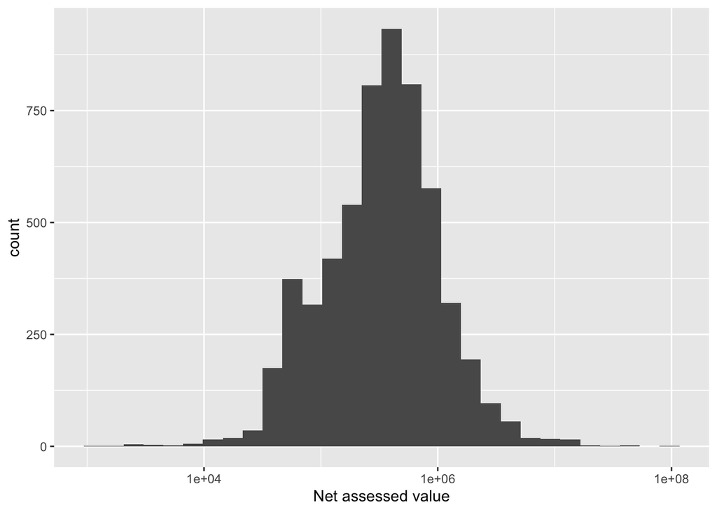

```r
ggplot(parcels) +
  geom_histogram(aes(x = NET_AV)) +
  scale_x_log10() +
  xlab("Net assessed value")
```

Seems like most parcels are valued at just under a million dollars, but some are worth tens of millions of dollars.

For the inundation scenarios, I combine all the layers into a single `sf` object.

```r
# Get layer names
inund_layers <- st_layers("HW2/data_hw2/inundation_scenarios.gpkg")$name

# Start with one layer and then row bind the others onto it with a loop
scenarios <- st_read("HW2/data_hw2/inundation_scenarios.gpkg", layer = inund_layers[1], quiet = TRUE)
for(i in 2:length(inund_layers)) {
  scenarios <- rbind(scenarios, read_sf("HW2/data_hw2/inundation_scenarios.gpkg", layer = inund_layers[i]))
}
```

Let’s look at one of these scenarios:

```r
tm_shape(st_geometry(filter(scenarios, GRIDCODE == 10))) +
    tm_fill(col = "lightblue") +
  tm_shape(ROI) +
  tm_borders()
```

[interactive chart not shown]

Seems like this represents current land area that would be inundated under the scenario in question.

### Spatial join

What we want here is the total value of all parcels that fall within the inundated area for each scenario.

```r
# Calculate the parcel areas
parcels$area <- st_area(parcels) # calculate area
units(parcels$area) <- with(ud_units, ha) # convert from m^2 to ha
parcels$area <- drop_units(parcels$area) # roundabout way of doing this,
# but it is less prone to human error to use the units package for conversions

# Do the join and summarize for each of the three variables
scenarios <- scenarios %>%
  st_join(parcels, join = st_intersects) %>%
  group_by(GRIDCODE) %>% # this is the ID of each scenario
  summarize(parcel_count = n(), net_value = round(sum(NET_AV)/1e6, 0), area = round(sum(area), 0))

# Rename GRIDCODE column
names(scenarios)[1] <- "scenario"
```

### Results: table

Now we can turn this into a table.

```r
st_drop_geometry(scenarios) %>%
  kbl(col.names = c("Sea-level rise (m)", "Parcel count", "Net loss ($m)", "Area flooded (ha)")) %>%
  kable_material(c("striped", "hover"))
```

| Sea-level rise (m) | Parcel count | Net loss ($m) | Area flooded (ha) |
| --- | --- | --- | --- |
| 1 | 60 | 51 | 43 |
| 2 | 89 | 88 | 108 |
| 3 | 227 | 195 | 189 |
| 4 | 620 | 566 | 301 |
| 5 | 1275 | 909 | 354 |
| 6 | 1863 | 1215 | 392 |
| 7 | 2196 | 1372 | 436 |
| 8 | 2614 | 1555 | 465 |
| 9 | 2958 | 1712 | 486 |
| 10 | 3287 | 1881 | 512 |

### Results: map

In the map, the numbers 1 through 10 represent the number of meters of sea-level rise associated with each scenario and the intensity of the color represents the amount of property value lost.

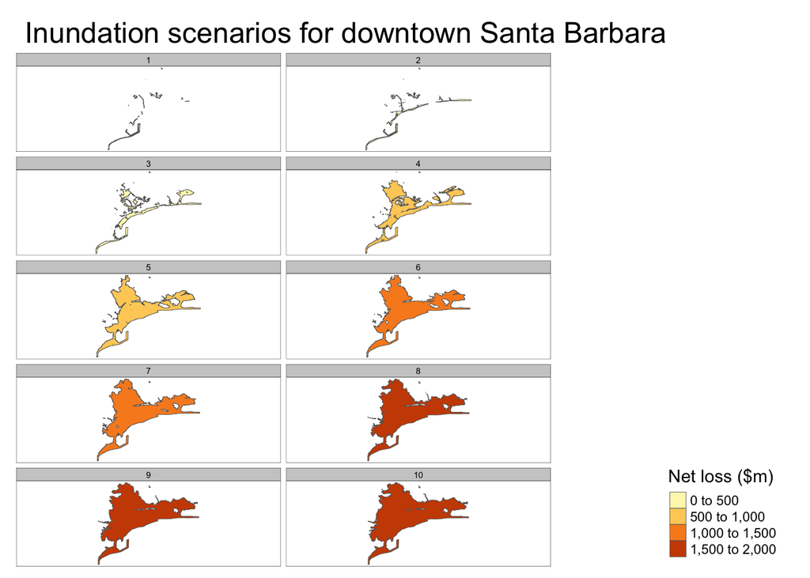

```r
tmap_mode("plot")
tm_shape(scenarios) +
  tm_polygons("net_value", title = "Net loss ($m)") +
  tm_facets(by = "scenario", nrow = 5, ncol = 2) +
  tm_layout(main.title = "Inundation scenarios for downtown Santa Barbara",
            legend.position = c("right", "bottom"))
```